# Projet de Techniques numériques : Estimation d’une provision pour dépréciation durable

LAVERNY Oskar, MARJOLET Pierre, BARRY Dieynaba

8 décembre 2017

# 1 Partie commentaire. (a supprimer avant de faire le rendu)

Tout n’est pas encore fait. j’ai setup les différentes sections, mais ne vous génez pas pour les modifier si vous le souhaitez. Il y a beaucoup a rédiger, quelques graphes a sortir et tout.

Le partage en deux fichiers ( un fichier générateur que l’on source) sera peut-être a supprimer aussi car YAHIA veut qu’on lui rende juste un raport et le code. On peut donc rendre un rapport ( le format compilé de ce fichier) et ce fichier ( non compile ). Il faudras donc copier dans le fichier le fichier générateur plutot que de le sourcer. Pour l’instant, on peut rester avec 2 fichier séparés, c’est plus simple de séparer les deux pour des question de gestion.

Sur la partie 2 actifs, ils sont générés, mais l’étude est encore a faire. De plus je ne suis pas sur d’avoir bien compris ce qu’il voulait.

Sur la partie un seul actif, il y a encore beacoup a faire aussi. Ne vous genez pas pour modifier ce que j’ai fait, c’est juste une base de travail pour l’instant !

# 2 Introduction

Raconter comment on a compris le sujet, histoire que si on c’est planter dans le code on s’en rendre peut-être compte ici.

**Approche de l’implémentation du problème :**

Pour implémenter le problème, nous avons considéré la PDD comme étant une variable aléatoire, et avons donc créé une fonction *rPDD* prenant en paramètres le nombre de simulations voulu ainsi que les différents paramètres du problème. Ainsi, les algorithmes de Monte-Carlo se font juste par la moyenne des simulation, comme pour n’importe quelle variable aléatoire, ce qui est cohérent avec la manière dont R fonctionne. Le générateur est paramètré pour pouvoir utiliser un raffinement par *Ponts Browniens* ou non. L’implémentation des *Ponts Browniens* suit à la lettre ce qui a été fait en TD ainsi que le dans le cours. La génération de deux actif corrélés s’appuie, de la même manière, sur une fonction *rPDD2* qui est juste une reprise du générateur de base avec des aléas corrélés via une implémentation de la solution de cholesky en dimention 2 vue en cours.

**Choix des paramètres par déffaut**

Pour l’ensemble des simulations, dans le cas où des re-paramètrages ne sont pas précisés, nous utiliserons les paramètres suivants par défaut :

- $S0=100$, le prix de l’actif en 0.
- $Sa=120$, la barrière.
- $\delta_t = \frac{1}{365}$, le pas de discrétisation a l’interieur d’une periode.
- $T = 1, 2, 5, 10, 15, 100$, le nombre de periodes.
- $\alpha=0.15, 0.2$, tel que $(1-\alpha)$ soit le seuil fixé dans l’énoncé.
- $r=0.015$, le taux d’intéret.
- $\sigma=0.45$, la volatilité du sous-jacent.
- $\Delta_\theta=10^{-5}$, la taille des différences finies.
- $M = 100$, le nombre de simulations de Monte-Carlo.

# 3 Un seul actif

Dans le cadre du modèle posé supra, nous avons estimé la PDD, ainsi que la probabilité qu’elle soit positive, par une méthode de monté-carlo naive, ainsi que par une méthode dite *raffinée* inclunant un pont brownien entre les points de discrétisation. Le nombre de periodes, $T$, varie comme demandé dans l’énoncé.

**Teaser** : Deux graphs de densitée de la PDD pour une seule periode ($T=1$), avec les paramètres par défaut, avec ou sans pont brownien.

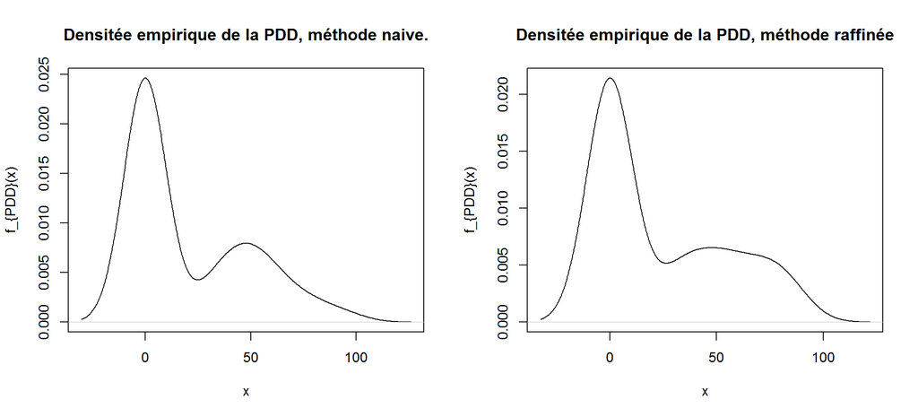

## 3.1 Estimation de la PDD

L’estimation de la PDD se fait par Monte-Carlo. On génère la PDD comme une variable aléatoire, et la probabilité qu’elle soit positive est calculée ensuite par la méthode de Monte-Carlo.

### 3.1.1 Méthode naive

La méthode naive consiste à considérer une génération de la valeur de l’actif en chaque point de discrétisation. Ainsi, la barrière sur les 6 derniers mois n’est pas calculée en continue, mais on utilise plutot une approximation par discrétisation simple, comme vu en cours. Cette méthode doit tendre à atteindre la barrière moins souvent qu’il faudrait, et implique donc un biais dans l’estimation.

#### 3.1.1.2 Résultats :

**Les jeux de re-paramètrages suivants ont été utilisés :**

- $\alpha = 0.15$ ou $\alpha = 0.2$
- $T = 1, 2, 5, 10, 15, 100$

Pour $\alpha = 0.15$, on obtient :

| Temps T | PDD obtenue (MC) | Probabilité que la PDD soit positive |
| --- | --- | --- |
| 1 | 24.56874 | 0.51 |
| 2 | 12.62267 | 0.43 |
| 5 | 27.99796 | 0.54 |
| 10 | 24.82368 | 0.62 |
| 15 | 32.46875 | 0.77 |
| 100 | 12.84111 | 1.00 |

Pour $\alpha = 0.2$, on obtient :

| Temps T | PDD obtenue (MC) | Probabilité que la PDD soit positive |
| --- | --- | --- |
| 1 | 28.14709 | 0.49 |
| 2 | 14.81794 | 0.41 |
| 5 | 30.57066 | 0.61 |
| 10 | 24.82898 | 0.65 |
| 15 | 28.06861 | 0.61 |
| 100 | 11.27028 | 0.94 |

### 3.1.2 Méthode raffinée par Pont brownien.

#### 3.1.2.2 Résultats :

Pour $\alpha = 0.15$, on obtient :

| Temps T | PDD obtenue (MC) | Probabilité que la PDD soit positive |
| --- | --- | --- |
| 1 | 27.82626 | 0.56 |
| 2 | 12.15912 | 0.43 |
| 5 | 29.10288 | 0.60 |
| 10 | 23.71695 | 0.70 |
| 15 | 33.56962 | 0.62 |
| 100 | 12.65463 | 0.97 |

Pour $\alpha = 0.2$, on obtient :

| Temps T | PDD obtenue (MC) | Probabilité que la PDD soit positive |
| --- | --- | --- |
| 1 | 25.45310 | 0.50 |
| 2 | 12.30598 | 0.35 |
| 5 | 26.83556 | 0.55 |
| 10 | 27.14321 | 0.71 |
| 15 | 33.37239 | 0.78 |
| 100 | 12.00017 | 0.97 |

## 3.2 Sensibilité de la PDD :

On va passer aux calculs de sensibilité de la PDD par rapport a certains paramètres, par la méthode des différences finies. On va donc grapher une fonction qui, a un paramètre ($\sigma$, $r$, $S_0$ ou $S_a$) donné, associe la dérivée partielle de la PDD.

**Les jeux de re-paramètrages suivants ont été utilisé :**

- $\alpha = 0.2$
- $T = 1, 2$

### 3.2.1 Par rapport à la valeur initiale $S_0$

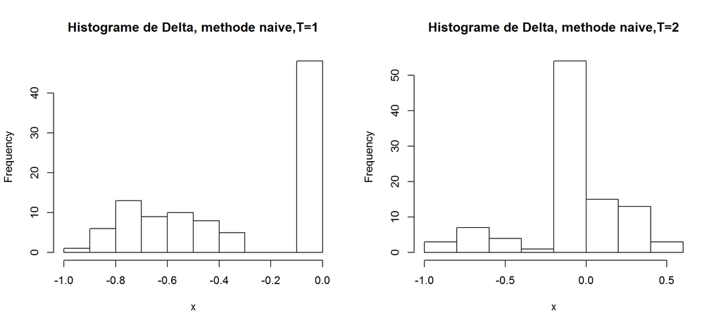

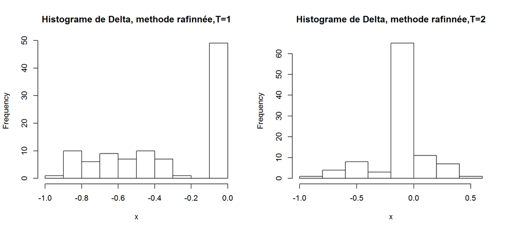

### 3.2.2 Par rapport à la barrière $S_a$

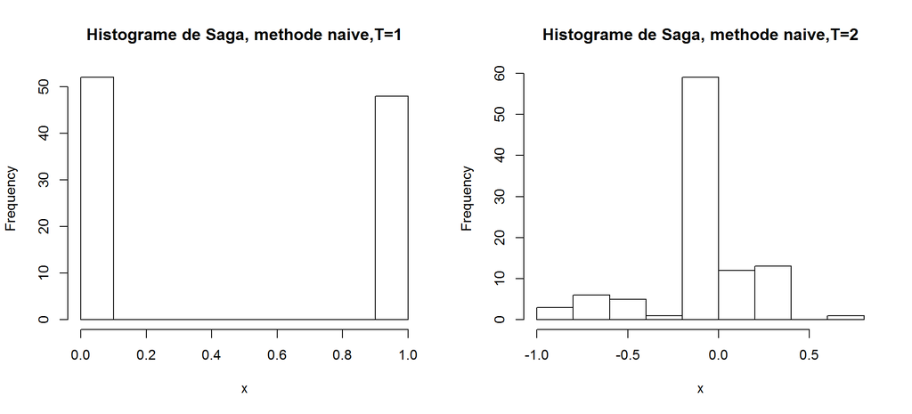

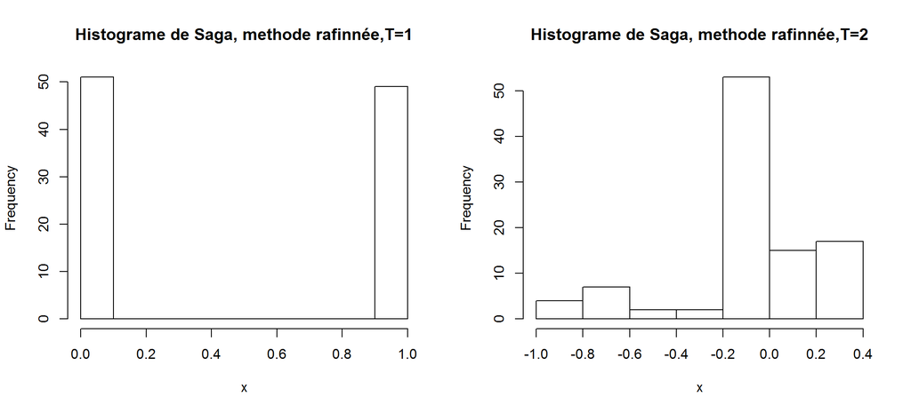

### 3.2.3 Par rapport au taux d’interet $r$

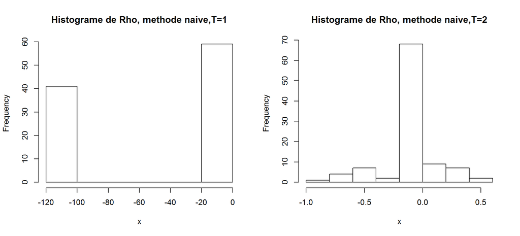

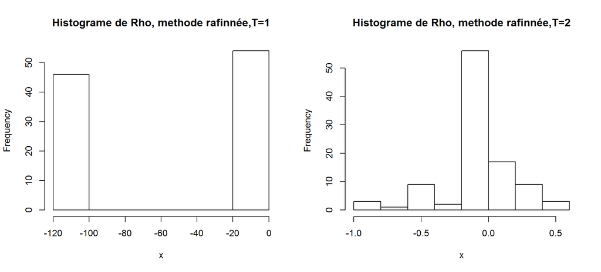

### 3.2.4 Par rapport à la volatilité $\sigma$

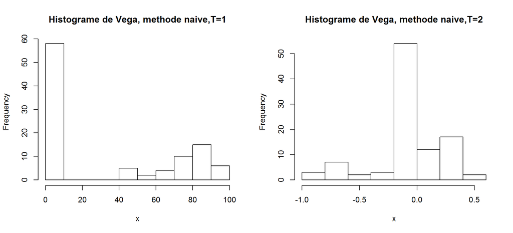

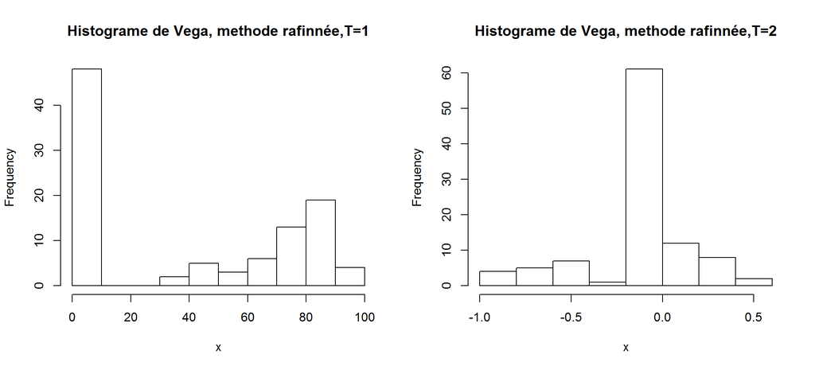

### 3.2.5 Résumé des dérivées obtenues :

[output not shown]

# 4 Deux actifs

On pourra étudier pour chaque modalité la corrélation entre les deux PDD.

On pourra même si on se chauffe un peu chercher la copule asociée aux deux PDD en fonction du coefficient de corrélation :)

## 4.2 Génération des deux PDD corrélées.

Exemple de code pour rho=1 :

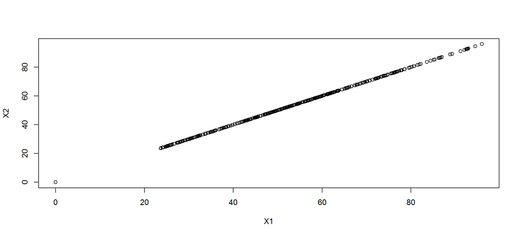

Normal : L’aléa etant comonotone, i.e les deux actifs sont les mêmes, il aurait été bizarre de ne pas passer la même PDD.

pour rho=0 :

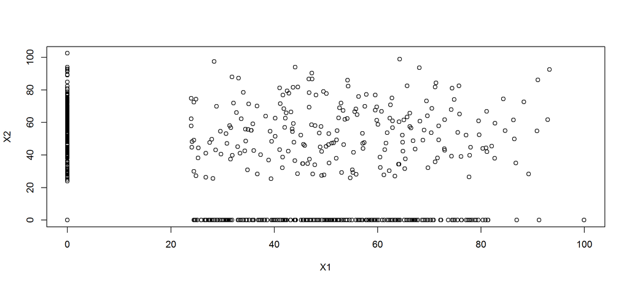

Cette fois, on ne lit rien : ce qui est aussi bon signe, les PDD de deux actifs indépendants sont indépendantes.

pour rho = 0.9

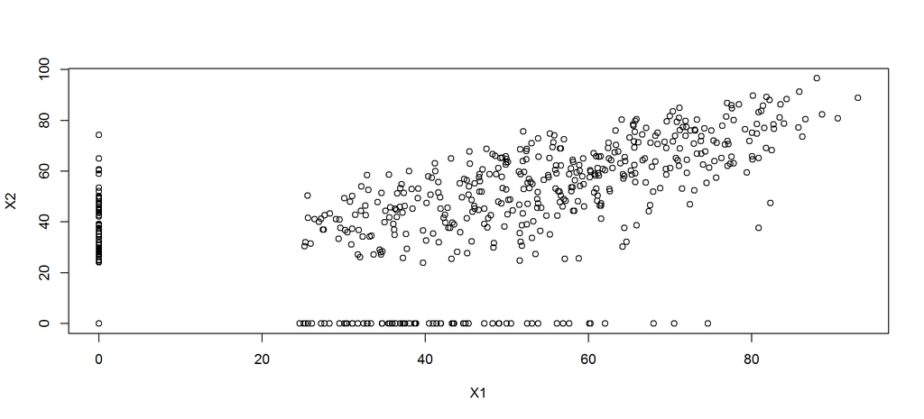

Ici par contre on voit bien une corrélation positive entre deux actifs positivement corrélés. ça me parait logique mais j’ai pas plus creusé pour l’instant, a voir.

## 4.3 Structure de dépendance obtenue

On peut même construire nos browniens corrélés en fonction de leur de kendall, et regarder comme évolue le taux de kendall des PDD en fonction du taux de kendall des browniens.